# Predictive Coding and Neural Networks

Audrey Dawson and Grace Moore

May 3rd, 2018

## Introduction

The scientific paper we read, *Application of Predictive Coding in the Evolution of Artificial Neural Networks*, was published in 2012 by H. Mohabeer and K. M. S Soyjaudah. This paper talked about building an internal model of an artificial neural network using predictive coding and optimizing this model with a Genetic Algorithm. They proposed using this predictive coding model to remove data redundancies in order to make analysis by this evolving neural network more efficient. It was determined through simulations that this method showed up to 80% improvement in efficiency in a lower complexity neural network compared to traditional methods.

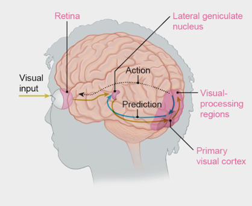

Diagram of upwards (yellow arrows) and downwards (blue arrows) human visual processing pathways (2).

Predictive coding models, like the ones developed in this paper, are designed to simulate how the human brain develops models to understand the world around it. Looking at the human visual processing system as an example of prediction in the human brain, it is clear that predictive coding is very similar to prediction error in humans. The human visual system is composed of two processing pathways for information to travel. Upwards pathways carry information from the eye through the optic nerve to the occipital lobe of the brain. Downward pathways move information from visual processing regions of the brain to lower processing regions such as the primary visual cortex where the signals are first received. Downward pathways carry the brain’s predictions based on its internal models gathered from previous experiences. These predictions serve to limit the actual amount of information that the brain has to process. This is because, when the two processing pathways interact, the difference in what is expected and what is experienced is reported back as prediction error. The brain uses prediction error to update and refine internal models of the world so that the error decreases over time and gradually the brain becomes better at predicting and does not have to interpret as much information. This is the idea behind predictive coding.

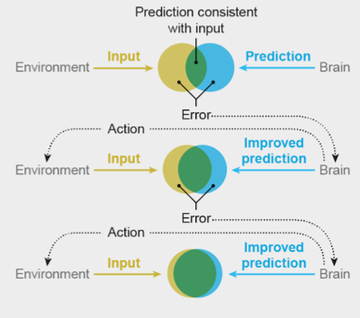

Diagram of prediciton error (2).:

## Results

To develop the predictive coding scheme, Bayes’ Theorem was utilized. Bayes’ Theorem describes the degrees of belief in the prediction of the current internal model based on the new observed evidence. Essentially, this is how well the model supports the new observation. This result can be used to determine how the internal model should be updated. This is similar to how the brain relies on predictions and new evidence to develop prediction errors. It uses these prediction errors to update its internal understanding. For Bayes’ Theorem, the prior belief in the model as well as how well the new evidence supports the given model contribute to this final result. Finally, once the model of the external world has been finalized on testing data, the neural network using the model can predict future conditions based on new inputs. The predictive coding scheme used in the paper also consisted of the general principle of Minimum Description Length to lead to the best compression of the data that was passed to the neural network.

Bayes’ Theorem is written as:

$$p(H|D) = \frac{p(D|H)p(H)}{p(D)}$$

where $p(H|D)$ is the likelihood of the model based on the evidence, $\frac{p(D|H)}{p(D)}$ is the likelihood of the evidence based on the model, and $p(H)$ is the prior belief in the model.

The data redundancy theory with predictive coding was tested by transmitting image data to a neural network in the way that the eye does to the brain, by providing minimal information that still allows the brain to construct the full image. Removing redundancies is important because redundant data can be impossible for a neural network to interpret efficiently. A predictive coding model for interpreting images was established with the ability to predict data at a location based on given neighboring data. The idea behind this was that if a data and its neighbors communicate almost the same information (are redundant) then the predictive encoder only needs to send the valuable (non-redundant) data to the neural network. It determines this data and sends it to the neural neural network to decode using the same internal predictive coding model. In this way the neural network recovers the original images with greater efficiency than if the data redundancy has not been reduced.

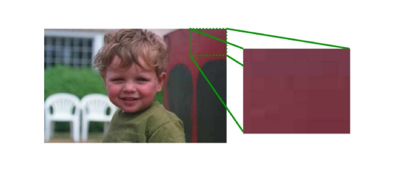

Example of redundant image data: The red pixels of the barn are considered to be redundant so the model would only receive a single pixel of the barn or a few pixels in key locations to understand the image (5).

In addition to increasing efficiency by reducing data, the model also uses NEAT, Neuroevolution of Augmented Topologies, which incorporates a genetic algorithm to produce a structure and weight for the neural network to optimize the decoding process. Genetic algorithms are a class of computational models which mimic evolution using a Darwinian fitness model. For this model, hundreds to thousands of possible structures and weights for the neural network were encoded onto chromosome-like data structures. Mutation and crossover were allowed to occur at rates of 0.8 and 0.01 respectively. These events allowed for the chromosomes to evolve and develop different possible solutions to the problem at hand. For each generation, the genetic algorithm uses a fitness function to evaluate the efficacy of each solution. Those with low fitness are removed while those with higher fitness remain. After each round of evolution, the chromosomes are looked at to determine if the termination condition has been reached. For this model, the condition was a plateau of solution improvement such that further evolution of the remaining chromosomes would not produce better results. When the termination condition is met, this indicates that a stable topology, or interconnection of the nodes, and weight has been found for the neural network.

## Discussion

Along with making data analysis more efficient by reducing redundancy, the ability to address complex data has interesting applications in psychology and neuroscience. For psychologists, studies of robotic children can answer questions about the role of predictive processing in the development of social behavior. Since our brains try to forecast the future when we interact with others to deduce their intentions or future actions our drive to reduce prediction errors may induce social behavior. This was tested in an android called iCub which had a neural network and a human-like body. It wasn’t programmed with the ability to socialize but helped move an object when another person struggled to because of its motivation to reduce prediction errors. This may be how infants develop social behaviors too.

[figure not shown]

iCub Learning (6).

As for neuroscience, predictive coding could provide insight into how and why people with ADHD or autism for example behave in the ways that they do. It is thought that certain behaviors occur due to changes in sensitivity to prediction errors. In any case, predictive coding can be used in robots to study these variations in human cognition. The eventual use of “cognitive mirroring” could be used. This would consist of a robot with predictive coding learning the preferences for predictability of a person and essentially becoming a model for that person’s brain that could be studied.

## Our Assessment

Overall, we found the paper did a good job of explaining the tools used to build and test the predictive coding scheme, but there were some areas of the model that were not as well explained as others. Throughout the paper there was mention of local and distributed data representations along with how the two were both used to emulate how the human brain processes information. It was challenging to understand their role in a neural network and the implication of using one or both of them. Additionally, the genetic algorithm was only touched on and not fully described. It would have been nice to have a bit more information about how the genetic algorithm was coded and perhaps been given the fitness function.

One of the biggest issue that we had with the paper was the idea of trying to create a machine with human-like learning abilities through the use of only an encoding of a step-by-step learning process. As Jordan stated in class and Mariama and Karen discussed in their presentation, human development is a continuous process and trying to use a discrete model to account for a continuous one is not possible by the pigeonhole principle. The question then becomes why should we even try to develop human-level AI? Furthermore, if we do succeed in someway, how much can we trust any conclusions made about human development from these machines? We don’t have the answers to these questions, but we feel that the work should continue to advance because developments in AI will likely lead to new technologies with potential uses in other fields. This was demonstrated in the paper we read that used the predictive coding neural network for greater efficiency with data analysis.

### Original Paper

1. Mohabeer, H, & Soyjaudah, K. M. S. (2012). Application of Predictive Coding in the Evolution of Artificial Neural Network. University of Mauritius.

### Additional Reading:

2. Kwon, Diana. (2018, March). Self-Taught Robots. Scientific American, 28-31.

### Other References:

3. “Bayes’ Theorem.” Wikipedia, Wikimedia Foundation, 10 Apr. 2018, en.wikipedia.org/wiki/Bayes%27_theorem.
4. “Genetic Algorithm.” Wikipedia. Wikipedia Foundation, 18 Apr. 2018.en.wikipedia.org/wiki/Genetic_algorithm

Images:

5. https://www.sciencedirect.com/science/article/pii/B9780128098257000079
6. http://csnblog.specs-lab.com

### Team Member Contributions:

Audrey found the paper and did all of the work of understanding and interpreting the predictive coding schemes (Bayes’ Theorem) and the data redundancy aspects of the paper. She also explored the applications of this model in the fields of psychology and neuroscience and made some interesting connections. She put a lot of time into this project and helped make the material more understandable. She also proofread everything.

Grace delved deeply into the genetic algorithm because of her interest in biology. She was really talented at synthesizing the information from the paper in order to make it clear to the audience. She contributed a lot of critical thinking about the results of the scientific paper and the implications of using predictive coding methods in other fields. She also put a lot of work into making the introduction to the presentation engaging and relatable. Grace also put stuff into a RMarkdown file.